# Testing Relationships

## Variables

- Dependent variable (a.k.a. $DV$, a.k.a. $Y$): The variable that *depends on* the independent variable
- Independent variable (a.k.a. $IV$, a.k.a. $X$): The variable whose variation we’re interested in
- E.g., Does depression symptom severity ($DV$) *depend on* age ($IV$)?
- E.g., Does campus belonging ($DV$) *depend on* citizenship ($IV$)?

## Testing Relationships

- Correlation: Testing the relationship between two continuous variables
- Linear regression: Testing the relationship between a continuous dependent variable and any kind of independent variable(s)
- Logistic regression: Testing the relationship between a dichotomous dependent variable and any kind of independent variable(s)

## Getting Started

```r
# Load packages
library(tidyverse)
library(here)

# Load data
hms_data <- readRDS(here("Healthy Minds Study", "Clean Data.rds"))

# Clean data
clean_data <- hms_data %>%
  drop_na()

# Filter data
tiny_data <- clean_data[sample(nrow(clean_data), 20),]

# Describe data
str(tiny_data)
```

```
tibble [20 x 21] (S3: tbl_df/tbl/data.frame)
 $ age                   : num [1:20] 30 22 22 18 21 20 24 42 22 22 ...
 $ gender                : chr [1:20] "Female" "Female" "Male" "Male" ...
 $ race_black            : logi [1:20] FALSE FALSE FALSE TRUE FALSE FALSE ...
 $ race_american_indian  : logi [1:20] FALSE FALSE FALSE FALSE FALSE FALSE ...
 $ race_asian            : logi [1:20] FALSE FALSE FALSE FALSE FALSE FALSE ...
 $ race_hispanic_latinx  : logi [1:20] FALSE TRUE FALSE FALSE FALSE FALSE ...
 $ race_pacific_islander : logi [1:20] FALSE FALSE FALSE FALSE FALSE FALSE ...
 $ race_mideast          : logi [1:20] FALSE FALSE FALSE TRUE FALSE FALSE ...
 $ race_white            : logi [1:20] TRUE TRUE TRUE FALSE TRUE TRUE ...
 $ race_other            : logi [1:20] FALSE FALSE FALSE FALSE FALSE FALSE ...
 $ citizen               : logi [1:20] TRUE TRUE TRUE TRUE TRUE TRUE ...
 $ financial_stress      : num [1:20] 3 4 2 3 3 2 2 2 2 2 ...
 $ weekly_hours_paid_work: num [1:20] 40 10 16 0 30 10 20 40 0 12.5 ...
 $ grades                : chr [1:20] "Mostly A's" "Mostly A's" "Mostly A's" "Mostly C's" ...
 $ belonging             : num [1:20] 3 6 5 2 1 6 6 2 1 1 ...
 $ depression            : num [1:20] 0 0 0 0 0 1 0 1 0 0 ...
 $ depression_severity   : num [1:20] 5 7 1 6 8 19 5 17 5 4 ...
 $ anxiety               : num [1:20] 0 0 0 0 1 1 0 1 0 0 ...
 $ anxiety_severity      : num [1:20] 4 5 2 6 12 12 6 17 6 4 ...
 $ past_year_therapy     : num [1:20] 0 0 0 1 0 1 0 1 0 0 ...
 $ past_year_medication  : num [1:20] 0 0 0 1 0 1 0 1 0 0 ...
```

## Correlation

Correlation: Measures the relationship between two continuous variables, and tests whether the two variables are related.

## Correlation

- Positive correlation: When one variable increases, the other variable also increases; when one variable decreases, the other variable also decreases (e.g., time studying and performance on an exam).
- Negative correlation: When one variable increases, the other variable *decreases* (e.g., birth weight and infant emotional problems).
- No correlation: When one variable increases, nothing happens to the other variable; they are independent of one another (e.g., shoe size and IQ)

## The Correlation Coefficient

The strength and direction of a correlation is given by the “correlation coefficient,” $r$.

- Positive correlation: $r > 0$, up to $r = 1$
- Negative correlation: $r < 0$, up to $r = -1$
- No correlation: $r = 0$

Correlations closer to 0 are weaker, while correlations closer to -1 or 1 are stronger.

## Visualizing Correlations

[figure not shown]

Note: Correlations assume that there is a *linear* relationship between $x_1$ and $x_2$.

## Visualizing Correlations

```r
tiny_data %>%
  ggplot(aes(x = depression_severity, y = anxiety_severity)) +
  geom_point() +
  ggpubr::stat_cor(aes(label = after_stat(r.label)))
```

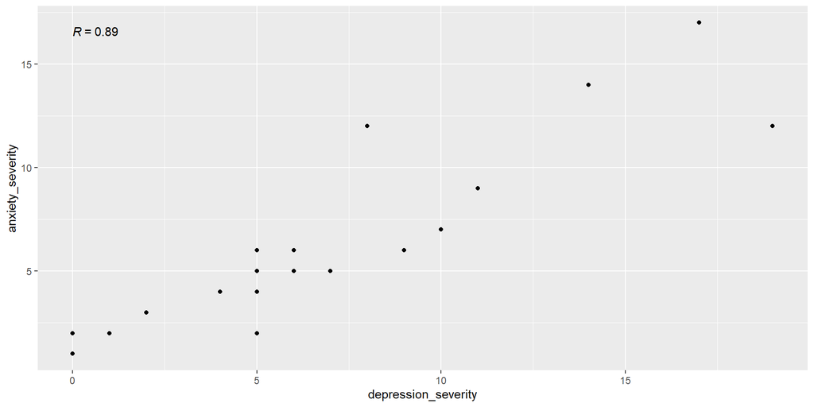

## Correlation Test

Moreover, the correlation coefficient comes with a statistical test.

- $x_1:$ the first variable
- $x_2:$ the second variable
- $r_{x_1,x_2}:$ the correlation between $x_1$ and $x_2$
- $h_0:$ $r_{x_1,x_2} = 0$
- $h_1: r_{x_1, x_2} \ne 0$

## Correlation Test

If the *null hypothesis* is that $r_{x_1,x_2}=0$, what does our *p*-value mean?

$p:$ the probability that we would see a correlation ($r_{x_1,x_2}$) as big as the one we observe if the null hypothesis were true

## The *r* Statistic

The $r$ statistic is calculated by asking: “When one variable goes up, what happens to the other variable?”

$r = \frac{\sum(x_i-\bar{x})(y_i-\bar{y})}{\sum(x_i-\bar{x})^2\sum(y_i-\bar{y})^2}$

- Positive correlation: $r > 0$, up to $r = 1$
- Negative correlation: $r < 0$, up to $r = -1$
- No correlation: $r = 0$

## The *r*-Distribution Under $h_0$

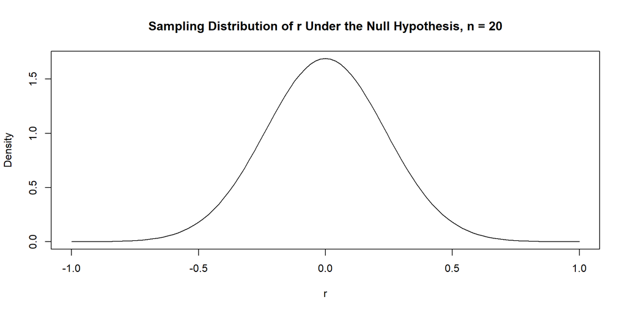

## The *r*-Distribution Under $h_0$

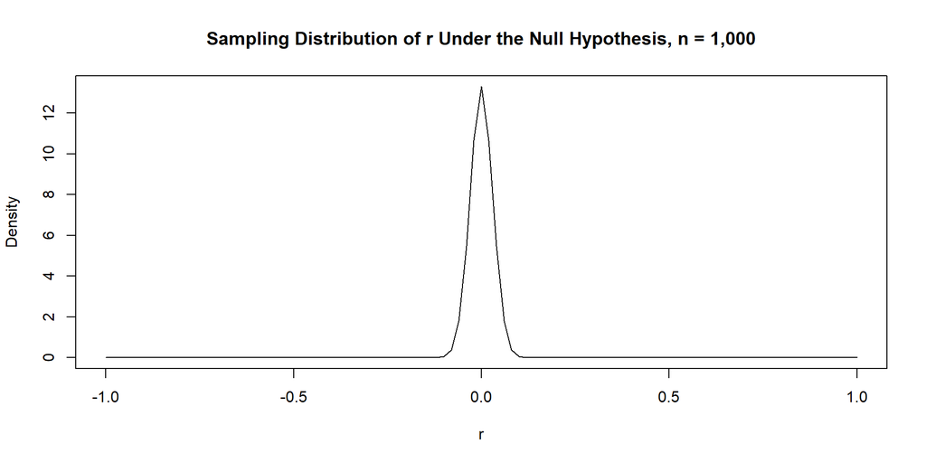

## The Test

```r
cor.test(tiny_data$depression_severity, tiny_data$anxiety_severity)
```

```
    Pearson's product-moment correlation

data:  tiny_data$depression_severity and tiny_data$anxiety_severity
t = 8.4583, df = 18, p-value = 1.099e-07
alternative hypothesis: true correlation is not equal to 0
95 percent confidence interval:
 0.7466890 0.9575991
sample estimates:
      cor
0.8938568
```

If the null hypothesis were true, how likely would we be to see a correlation coefficient as large as .89?

## Confidence Intervals

For tests of relationships, it’s usually not enough to just say that there is some positive relationship. Usually, we want to say just how strong (or weak) the relationship is. Our correlation test tells us that there is *some* positive relationship, but how do we say what that relationship is likely to be in the full population? For this, we need to calculate a confidence interval around *r*.

## Confidence Intervals

R gives us a confidence interval along with our correlation test results:

```r
cor.test(tiny_data$depression_severity, tiny_data$anxiety_severity)
```

```
    Pearson's product-moment correlation

data:  tiny_data$depression_severity and tiny_data$anxiety_severity
t = 8.4583, df = 18, p-value = 1.099e-07
alternative hypothesis: true correlation is not equal to 0
95 percent confidence interval:
 0.7466890 0.9575991
sample estimates:
      cor
0.8938568
```

We can say with 95% certainty that the true population correlation falls between $r = .75$ and $r = .96$.

## Confidence Intervals

We can also calculate this the hard way, by coming up with the sampling distribution for our observed $r$.

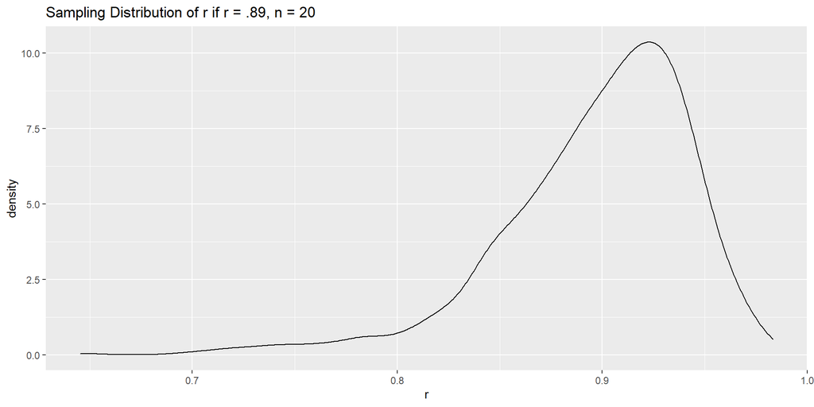

## Reporting the Test

In our sample, we found a strong positive correlation between depression symptom severity and anxiety symptom severity (*r* = .89). We conducted a correlation test to test whether this observed relationship indicates a true relationship in the population. The null hypothesis was that there was no true correlation between these variables in the population. With a p-value < .001, we reject the null hypothesis and conclude that depression symptom severity and anxiety symptom severity are positively correlated among the full population of college students. In addition, we are 95% certain that the true correlation coefficient falls between .75 and .96.

## Visualizing the Test

```r
tiny_data %>%
  ggplot(aes(x = depression_severity, y = anxiety_severity)) +
  geom_point() +
  ggpubr::stat_cor()
```

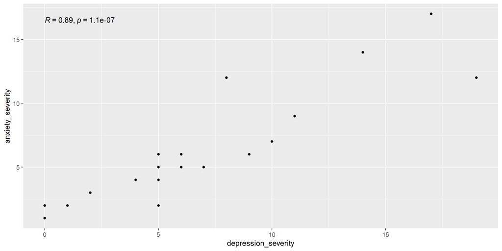

## Linear Regression

Linear regression is an extension of correlation. Now, in addition to showing the strength and direction of a relationship, we can:

1. Show how much the DV increases/decreases as the IV increases, in units
2. Show how much multiple IVs relate to a single DV

## The “Linear Model”

A great deal of statistics is based on the “linear model.” This might sound intimidating, but it’s actually something you learned in Algebra I.

$y = mx + b$

$\,$

$E(Y) = \beta_0 + \beta_1X + \epsilon$

## Visualizing the Linear Model

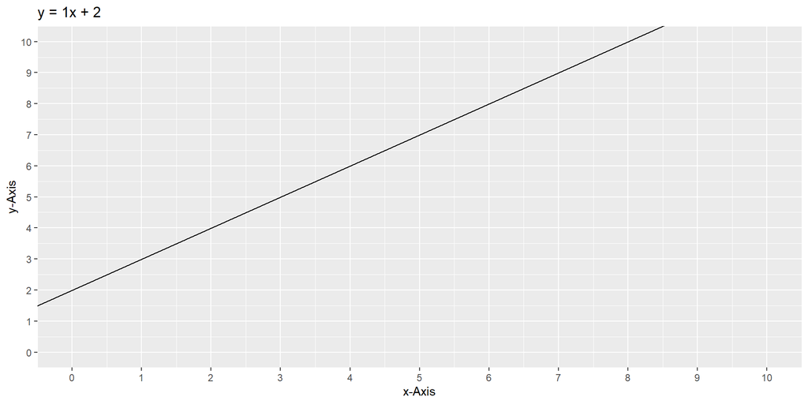

## Visualizing the Linear Model

```r
tiny_data %>%
  ggplot(aes(x = depression_severity, y = anxiety_severity)) +
  geom_point() +
  geom_smooth(method = "lm", formula = "y ~ x", se = F)
```

[output not shown]

$E(Y) = \beta_0 + \beta_1X + \epsilon$

## Estimating the Linear Model

Just like the population mean $\mu$ is estimated with $\bar{x}$, our population coefficients $\beta$ are estimated with $b$.

$E(Y) = \beta_0 + \beta_1X + \epsilon$ $\leftarrow$ our *population* linear model

becomes…

$\hat{Y} = b_0 + b_1X + e$ $\leftarrow$ our *estimated* linear model

## Error in the Linear Model

The linear model is unique because it accounts for “error” - all of the confounding factors that keep us from having a perfect 1:1 relationship between $X$ (our $IV$) and $Y$ (our $DV$).

When we estimate a linear model with our dataset, we can actually see what these errors are. We call these errors “residuals” and refer to them with $e$.

## Error in the Linear Model

In fact, error is so essential to the linear model that we can’t estimate our models without it. We pick our regression line (the “line of best fit”) by figuring out what line minimizes the residuals.

## Assumptions in the Linear Model

There are many assumptions that we make when we use a linear model. I would like to focus on **two**:

1. The relationship between $X$ (the $IV$) and $Y$ (the $DV$) is *linear*
2. Our residuals represent *random error*: they are normally distributed and don’t depend on $X$

## Assumptions in the Linear Model

1. The relationship between $X$ (the $IV$) and $Y$ (the $DV$) is *linear*

## Assumptions in the Linear Model

2. Our residuals represent *random error*: they are normally distributed and don’t depend on $X$

## Assumptions in the Linear Model

2. Our residuals represent *random error*: they are normally distributed and don’t depend on $X$

```r
my_lm <- lm(data = tiny_data, anxiety_severity ~ depression_severity)
residuals <- resid(my_lm)

hist(residuals)
```

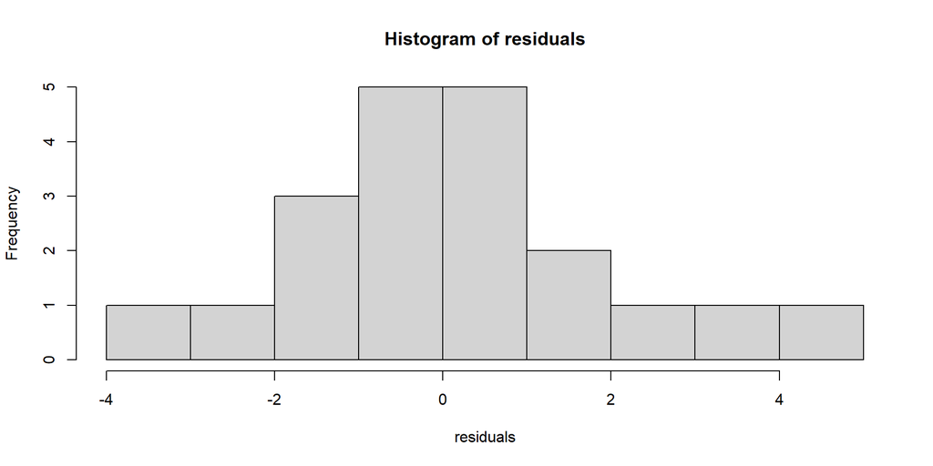

## Assumptions in the Linear Model

2. Our residuals represent *random error*: they are normally distributed and don’t depend on $X$

```r
my_lm <- lm(data = tiny_data, anxiety_severity ~ depression_severity)
residuals <- resid(my_lm)

plot(tiny_data$depression_severity, residuals)
```

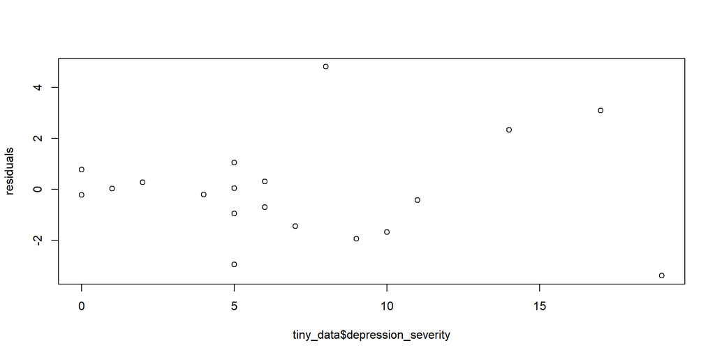

## Recap

- The linear model describes the linear relationship between $X$ (our $IV$) and $Y$ (our $DV$)
- We estimate the regression line by finding the line that minimizes the residuals
- We’re interested in learning about $\beta:$ the slope between $X$ and $Y$
- The relationship between $X$ and $Y$ has to be linear, and our residuals have to be totally random

## Estimating the Linear Model in R

```r
my_lm <- lm(data = tiny_data, anxiety_severity ~ depression_severity)

summary(my_lm)
```

```
Call:
lm(formula = anxiety_severity ~ depression_severity, data = tiny_data)

Residuals:
    Min      1Q  Median      3Q     Max
-3.3832 -1.0690 -0.0826  0.8493  4.8172

Coefficients:
                    Estimate Std. Error t value Pr(>|t|)
(Intercept)          1.21883    0.75793   1.608    0.125
depression_severity  0.74549    0.08814   8.458  1.1e-07 ***
---
Signif. codes:  0 '***' 0.001 '**' 0.01 '*' 0.05 '.' 0.1 ' ' 1

Residual standard error: 1.996 on 18 degrees of freedom
Multiple R-squared:  0.799, Adjusted R-squared:  0.7878
F-statistic: 71.54 on 1 and 18 DF,  p-value: 1.099e-07
```

$\hat{Y} = b_0 + b_1X + e$

## The $b$ Statistic

The $b$ statistic (or “coefficient”) represents the slope of the line relating $X$ to $Y$

- Positive relationship: $b > 0$
- Negative relationship: $b < 0$
- No relationship: $b = 0$
- $h_0:b=0$
- $h_1:b\ne0$

Like any statistic, $b$ has a sampling distribution under $h_0$ that we will use to determine our *p*-value.

## Testing our $b$ Coefficient

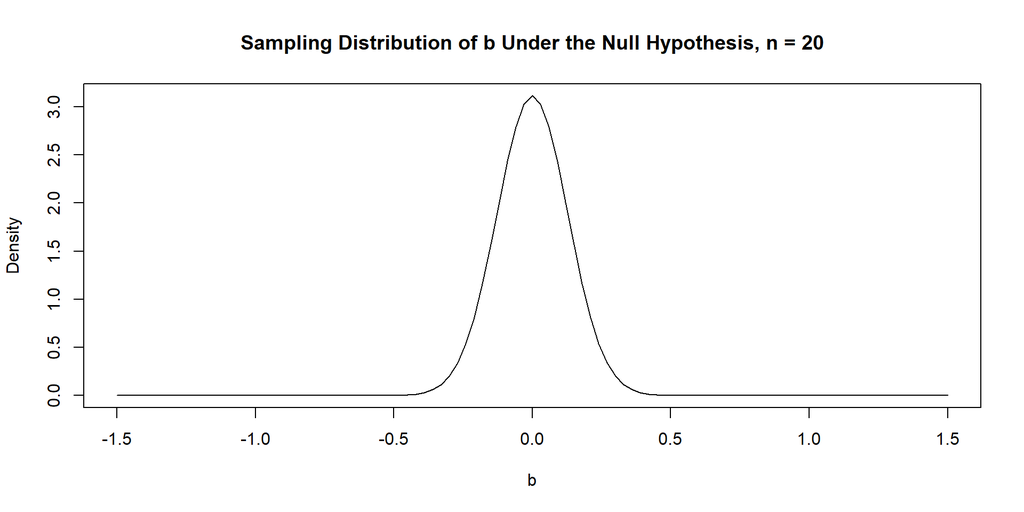

## Testing our $b$ Coefficient

```r
summary(my_lm)
```

```
Call:
lm(formula = anxiety_severity ~ depression_severity, data = tiny_data)

Residuals:
    Min      1Q  Median      3Q     Max
-3.3832 -1.0690 -0.0826  0.8493  4.8172

Coefficients:
                    Estimate Std. Error t value Pr(>|t|)
(Intercept)          1.21883    0.75793   1.608    0.125
depression_severity  0.74549    0.08814   8.458  1.1e-07 ***
---
Signif. codes:  0 '***' 0.001 '**' 0.01 '*' 0.05 '.' 0.1 ' ' 1

Residual standard error: 1.996 on 18 degrees of freedom
Multiple R-squared:  0.799, Adjusted R-squared:  0.7878
F-statistic: 71.54 on 1 and 18 DF,  p-value: 1.099e-07
```

If the null hypothesis were true, how likely would we be to see a $b$ coefficient as large as .74?

## Confidence Intervals for the $b$ Coefficient

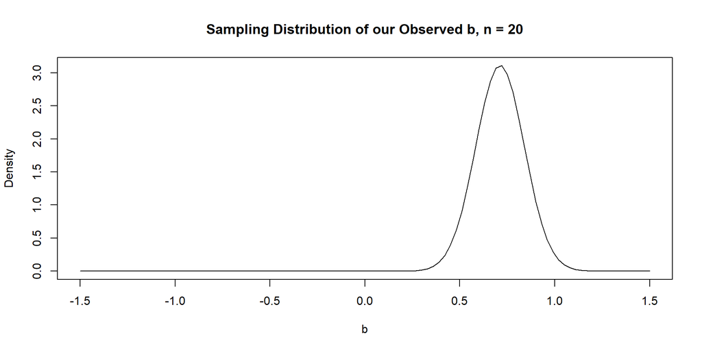

## Confidence Intervals for the $b$ Coefficient

```r
confint(my_lm)
```

```
                         2.5 %    97.5 %
(Intercept)         -0.3735134 2.8111779
depression_severity  0.5603228 0.9306608
```

## Visualizing the Test

```r
tiny_data %>%
  ggplot(aes(x = depression_severity, y = anxiety_severity)) +
  geom_point() +
  geom_smooth(method = "lm", formula = "y ~ x")
```

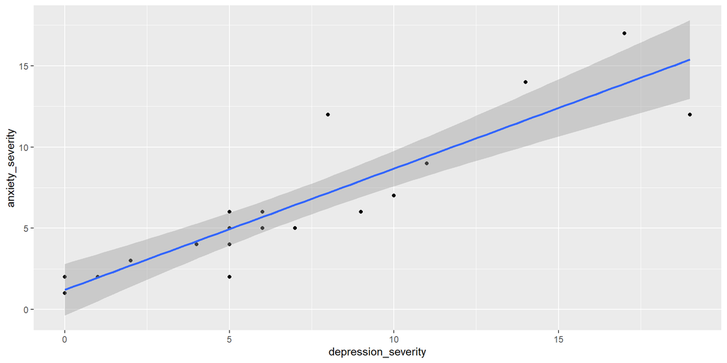